# Overview of REPHY data

We investigate the [REPHY database](https://www.seanoe.org/data/00361/47248/). See [user manual](https://archimer.ifremer.fr/doc/00409/52017/52675.pdf).

## Todo

- Download REPHY data
- Read REPHY data
- Clean and extract nutrients
- Get an overview of the data - spatial and temporal coverage
- Fix figure size
- Fix NA coverage (either go wide, either remove na cols)
- Plot time series of nutrient grouped by areas/regions
- Plot seasonality of different nutrient variables
- Check sampling methods
- Plot raw time series of different nutrients
- Check “niveau de qualité”
- Remove “douteux” samples
- Check levels in the water column
- Filter only surface depth sampling

## Setup

```r
library(renv)
renv::load()
library(targets)
library(here)
tar_config_set(
  store = here::here("_targets")
)
library(ggplot2)
library(hrbrthemes)
library(dplyr)
library(sf)
devtools::load_all()
riversea::nice_theme()
```

We begin by reading the `.csv` file, which is not an easy step because of the formatting issue. One it’s done we can have a look at the data structure.

```r
raw_data <- tar_read(rephy_raw_data)
str(raw_data)
```

```
tibble [1,081,642 × 56] (S3: tbl_df/tbl/data.frame)
 $ Lieu de surveillance : Entité de classement : Libellé   : chr [1:1081642] "001 - Frontière belge - Cap Gris Nez" "001 - Frontière belge - Cap Gris Nez" "001 - Frontière belge - Cap Gris Nez" "001 - Frontière belge - Cap Gris Nez" ...
 $ Lieu de surveillance : Identifiant                      : num [1:1081642] 1e+06 1e+06 1e+06 1e+06 1e+06 ...
 $ Lieu de surveillance : Mnémonique                       : chr [1:1081642] "001-P-166" "001-P-166" "001-P-166" "001-P-166" ...
 $ Lieu de surveillance : Libellé                          : chr [1:1081642] "Strouanne" "Strouanne" "Strouanne" "Strouanne" ...
 $ Passage : Identifiant interne                           : num [1:1081642] 46823 46823 46823 46823 46823 ...
 $ Passage : Date                                          : chr [1:1081642] "09/02/1989" "09/02/1989" "09/02/1989" "09/02/1989" ...
 $ Passage : Mois                                          : num [1:1081642] 2 2 2 2 2 7 7 7 7 7 ...
 $ Passage : Année                                         : num [1:1081642] 1989 1989 1989 1989 1989 ...
 $ Passage : Heure                                         : 'hms' num [1:1081642] 15:00:00 15:00:00 15:00:00 15:00:00 ...
  ..- attr(*, "units")= chr "secs"
 $ Coordonnées passage : Coordonnées minx                  : num [1:1081642] 1.68 1.68 1.68 1.68 1.68 ...
 $ Coordonnées passage : Coordonnées maxx                  : num [1:1081642] 1.68 1.68 1.68 1.68 1.68 ...
 $ Coordonnées passage : Coordonnées miny                  : num [1:1081642] 50.9 50.9 50.9 50.9 50.9 ...
 $ Coordonnées passage : Coordonnées maxy                  : num [1:1081642] 50.9 50.9 50.9 50.9 50.9 ...
```

[output cut: 43 more lines]

In particular, we can look at the what parameters are recorded.

```r
raw_data |>
  select("Résultat : Code paramètre", "Résultat : Libellé paramètre") |>
  distinct() |>
  print(n = 40)
```

```
# A tibble: 38 × 2
   `Résultat : Code paramètre` `Résultat : Libellé paramètre`
   <chr>                       <chr>
 1 NH4                         Ammonium
 2 OXYGENE                     Oxygène dissous
 3 SALI                        Salinité
 4 TEMP                        Température de l'eau
 5 TURB                        Turbidité
 6 CHLOROA                     Chlorophylle a
 7 PO4                         Phosphate
 8 SIOH                        Silicate
 9 NO3+NO2                     Nitrate + nitrite
10 TURB-FNU                    Turbidité FNU
11 Allo                        Alloxanthin
12 Anth                        Antheraxanthin
```

[output cut: 26 more lines]

Here are the parameters that are relevant for our study.

```r
raw_data |>
  select("Résultat : Code paramètre", "Résultat : Libellé paramètre") |>
  distinct() |>
  filter(`Résultat : Code paramètre` %in% rephy_nutrient_codes())
```

```
# A tibble: 4 × 2
  `Résultat : Code paramètre` `Résultat : Libellé paramètre`
  <chr>                       <chr>
1 NH4                         Ammonium
2 OXYGENE                     Oxygène dissous
3 PO4                         Phosphate
4 NO3+NO2                     Nitrate + nitrite
```

Next, we clean the table. Rename and select the relevant columns. Filter for the parameters above.

```r
data <- tar_read(rephy_data)
str(data)
```

```
tibble [101,894 × 13] (S3: tbl_df/tbl/data.frame)
 $ site_id        : num [1:101894] 1e+06 1e+06 1e+06 1e+06 1e+06 ...
 $ site_label     : chr [1:101894] "Strouanne" "Strouanne" "Strouanne" "Strouanne" ...
 $ sample_id      : num [1:101894] 50157 50157 50158 50158 50159 ...
 $ date           : Date[1:101894], format: "1989-02-09" "1989-02-09" ...
 $ level          : chr [1:101894] "Surface (0-1m)" "Surface (0-1m)" "Surface (0-1m)" "Surface (0-1m)" ...
 $ depth          : num [1:101894] 0.5 0.5 0.5 0.5 0.5 0.5 0.5 0.5 0.5 0.5 ...
 $ depth_unit     : chr [1:101894] "m" "m" "m" "m" ...
 $ longitude      : num [1:101894] 1.68 1.68 1.68 1.68 1.68 ...
 $ latitude       : num [1:101894] 50.9 50.9 50.9 50.9 50.9 ...
 $ parameter_code : chr [1:101894] "NH4" "OXYGENE" "NH4" "OXYGENE" ...
 $ parameter_label: chr [1:101894] "Ammonium" "Oxygène dissous" "Ammonium" "Oxygène dissous" ...
 $ value          : num [1:101894] 0.15 9.23 0.15 7.39 0.15 ...
 $ unit           : chr [1:101894] "µmol.l-1" "mg.l-1" "µmol.l-1" "mg.l-1" ...
```

## Data completeness

For each nutrient parameter, here is the number of observations, the number of distinct sampling sites, and the covered date range.

```r
riversea::summarise_rephy_coverage(data) |>
  knitr::kable(digits = 1)
```

| parameter_code | n | n_sites | year_min | year_max |
| --- | --- | --- | --- | --- |
| NH4 | 19281 | 153 | 1989 | 2022 |
| NO3+NO2 | 18853 | 149 | 2001 | 2022 |
| OXYGENE | 44436 | 235 | 1988 | 2022 |
| PO4 | 19324 | 150 | 1992 | 2022 |

We notice that we have more than twice as many points for the oxygen than for the nutrients. The number of points for the other nutrients are closed to one another, suggesting that when one nutrient is measured the others are too.

## Spatial coverage

We map the distinct sampling sites to get a sense of the spatial resolution of the REPHY network.

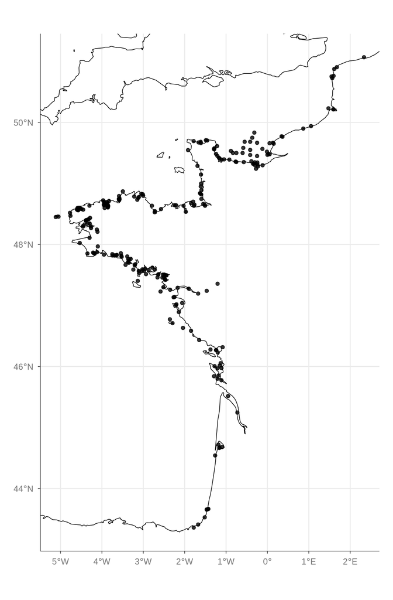

```r
riversea::plot_rephy_map(data, facet = FALSE)
```

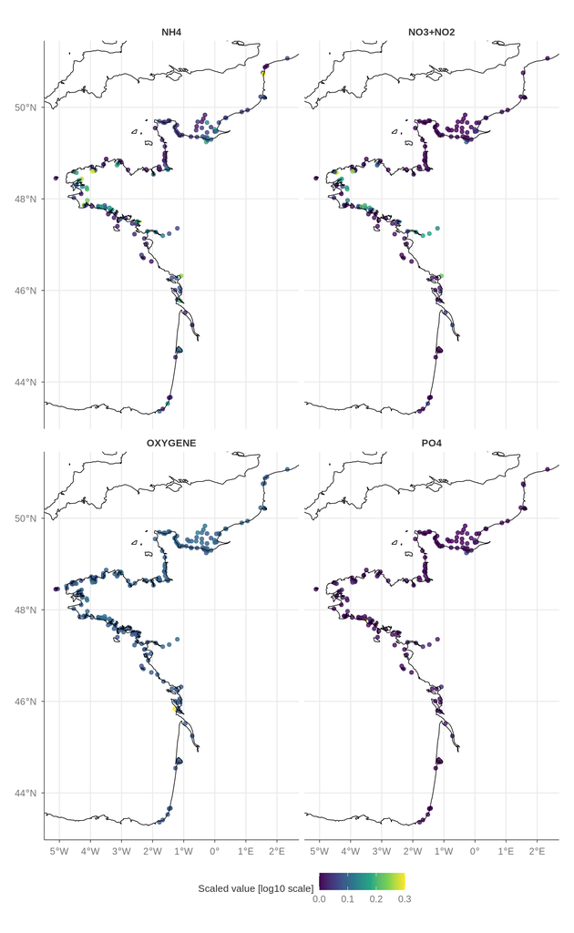

```r
riversea::plot_rephy_map(data, facet = TRUE)
```

Interstingly we see that concentration of nitrogen derivatives, ammonium and nitrite + nitrate, are higher on Britany coast. This could be expected because of agricultural nutrient runoff.

## Temporal coverage

Here is the number of observations per parameter, by year.

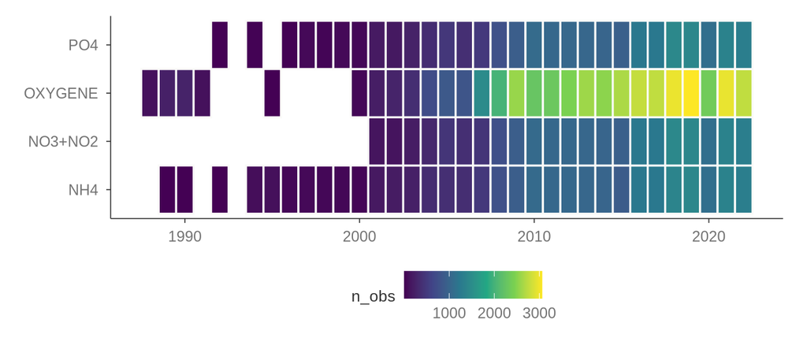

```r
riversea::plot_rephy_temporal_coverage(data)
```

## Yearly trends by district

To plot a yearly time series per nutrient we need a geographic grouping. We reuse the DCE hydrographic districts already used for the river food web (`hydrographic_area`, built from the SANDRE coastal/transitional water body shapefiles), so that river and coastal analyses stay on the same spatial units. Each site is joined to the district it falls in, dropping the few sites too far from any polygon to be matched reliably.

```r
district_data <- tar_read(rephy_district_data)

sites <- data |>
  distinct(site_id, longitude, latitude) |>
  mutate(matched = site_id %in% district_data$site_id)

hydro_area <- tar_read(hydrographic_area) |>
  filter(district %in% unique(district_data$district))
```

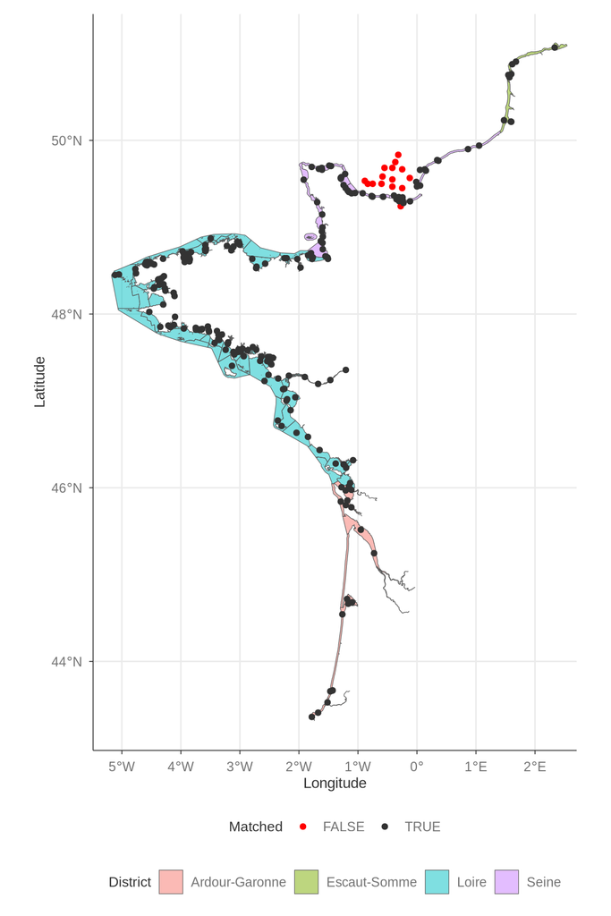

```r
ggplot() +
  geom_sf(data = hydro_area, aes(fill = district), alpha = 0.5) +
  geom_point(data = sites, aes(x = longitude, y = latitude, color = matched)) +
  coord_sf(xlim = range(sites$longitude), ylim = range(sites$latitude)) +
  scale_color_manual(values = c(`TRUE` = "grey20", `FALSE` = "red")) +
  labs(fill = "District", color = "Matched", x = "Longitude", y = "Latitude") +
  theme(legend.box = "vertical")
```

507 points out of 101894 could not be matched to a district and were dropped. We then average nutrient concentrations by year and district.

```r
yearly <- tar_read(rephy_yearly)
str(yearly)
```

```
tibble [321 × 5] (S3: tbl_df/tbl/data.frame)
 $ year          : num [1:321] 2007 2008 2009 2010 2011 ...
 $ district      : chr [1:321] "Ardour-Garonne" "Ardour-Garonne" "Ardour-Garonne" "Ardour-Garonne" ...
 $ parameter_code: chr [1:321] "NH4" "NH4" "NH4" "NH4" ...
 $ value         : num [1:321] 2.07 2.39 2.52 1.58 1.76 ...
 $ n             : int [1:321] 24 54 62 160 142 144 151 165 163 223 ...
```

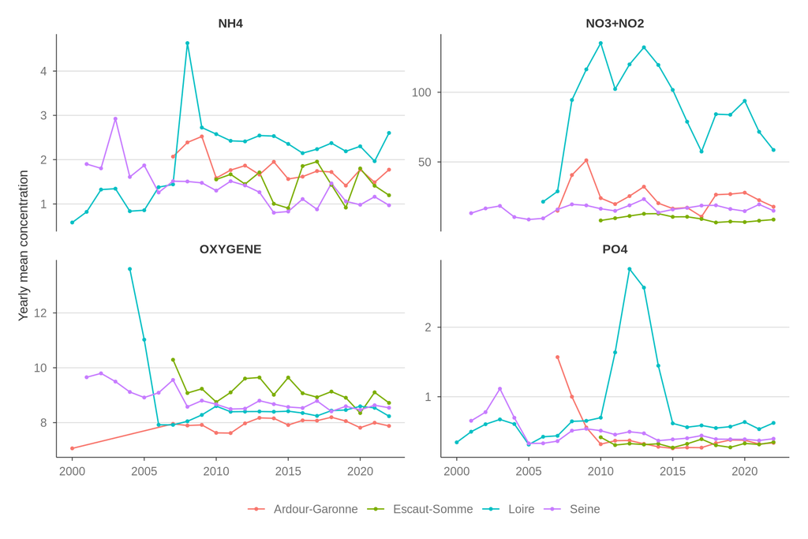

```r
riversea::plot_rephy_temporal_trend(yearly |> filter(year >= 2000))
```

The Loire district stands out with clearly higher nitrate + nitrite and phosphate concentrations, consistent with agricultural nutrient runoff from the Loire basin. We filter early years because we have very few observations.

## Seasonal trends

### Distribution of overall sampling effort

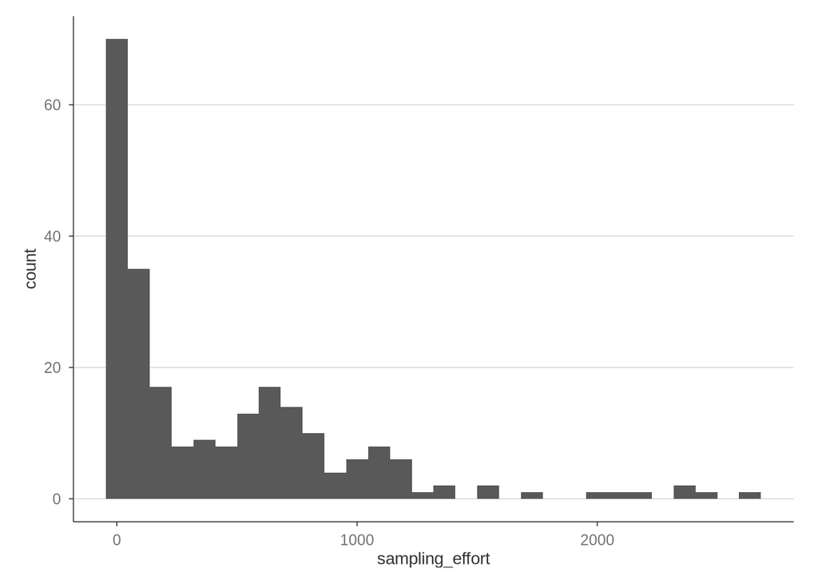

```r
site_sampling_effort <- data |>
  group_by(site_id) |>
  summarise(sampling_effort = n()) |>
  arrange(desc(sampling_effort))

ggplot(site_sampling_effort, aes(x = sampling_effort)) +
  geom_histogram()
```

### Station most sampled

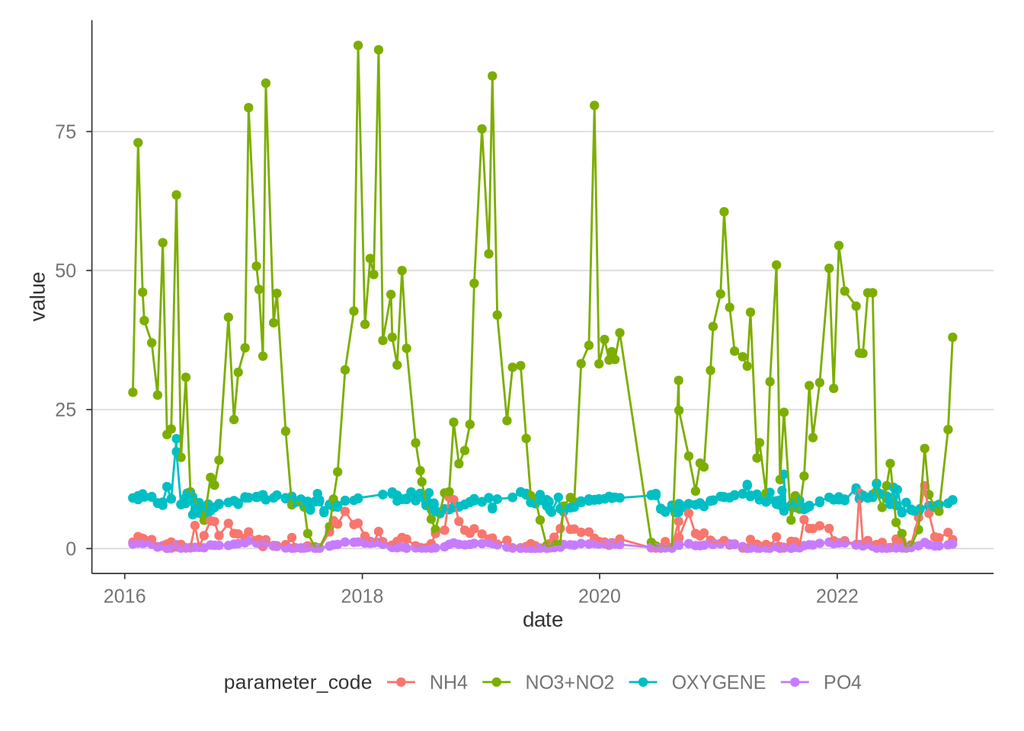

```r
site_most_point <- site_sampling_effort |>
  slice(1) |>
  pull(site_id) |>
  first()

data_most_point <- data |>
  filter(site_id == site_most_point) |>
  filter(lubridate::year(date) > 2015)

ggplot(data_most_point, aes(x = date, y = value, color = parameter_code)) +
  geom_point() +
  geom_line()
```

### Station sampled randomly

We sample random stations and plot their 2020 seasonal trend, to get an idea of the sampling effort during the year, per variable.

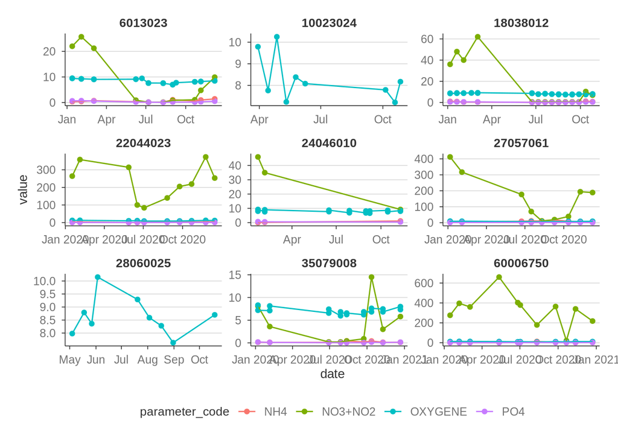

```r
data_2020 <- data |>
  filter(lubridate::year(date) == 2020)

selected_sites <- data_2020 |>
  pull(site_id) |>
  unique() |>
  sample(9)

selected_data <- data_2020 |>
  filter(site_id %in% selected_sites)

ggplot(selected_data, aes(x = date, y = value, color = parameter_code)) +
  geom_point() +
  geom_line() +
  facet_wrap(~site_id, scales = "free")
```

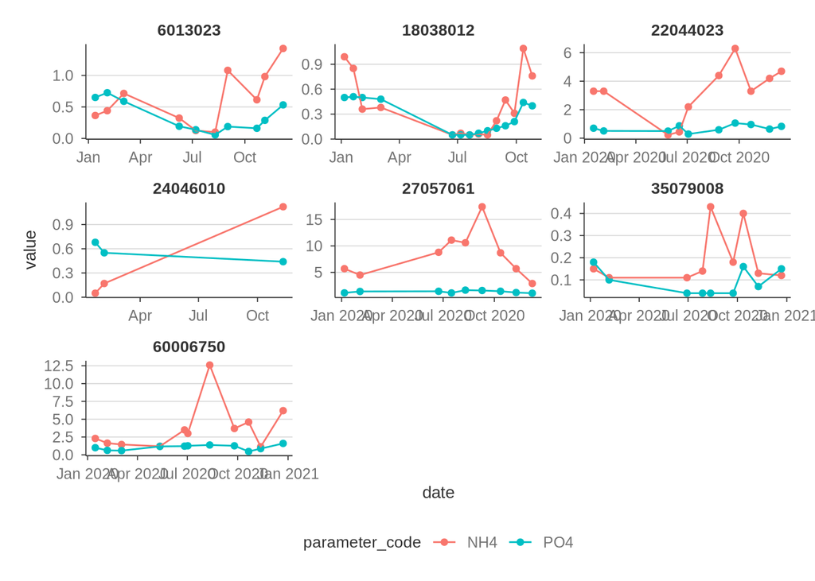

```r
ggplot(
  selected_data |> filter(parameter_code %in% c("NH4", "PO4")),
  aes(x = date, y = value, color = parameter_code)
) +
  geom_point() +
  geom_line() +
  facet_wrap(~site_id, scales = "free")
```

We can also have an idea of the average sampling effort per month per variable, to assess whether some nutrients are sampled during specific period each year, or not.

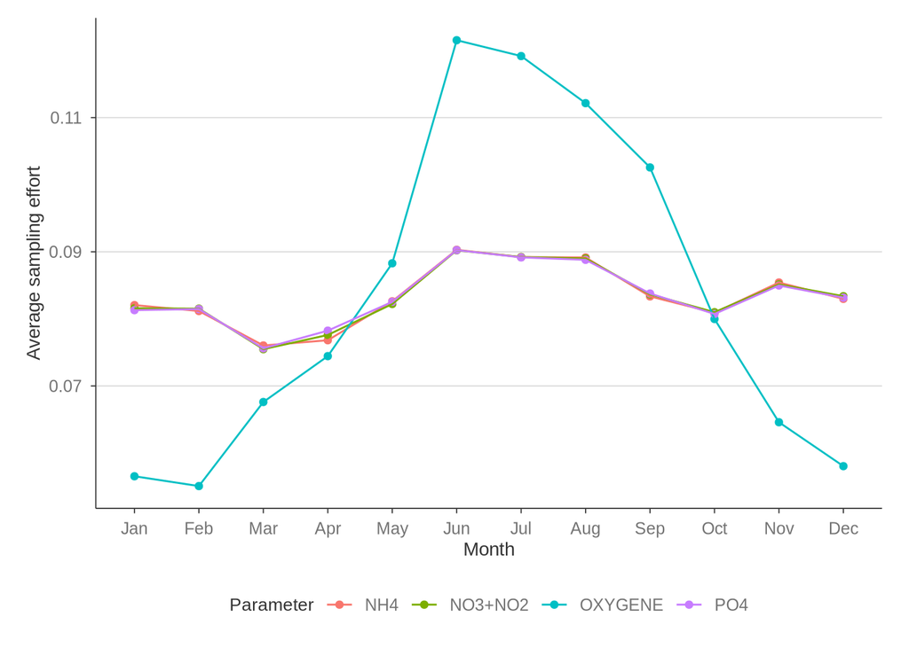

```r
sampling_per_month <- data |>
  mutate(month = as.factor(lubridate::month(date, label = TRUE))) |>
  left_join(
    data |>
      group_by(parameter_code) |>
      summarise(n_tot = n(), .groups = "drop"),
    by = join_by(parameter_code)
  ) |>
  group_by(parameter_code, month, n_tot) |>
  summarise(sampling_effort = n(), .groups = "drop") |>
  mutate(
    rel_sampling_effort = sampling_effort / n_tot
  )

ggplot(
  sampling_per_month,
  aes(x = month, y = rel_sampling_effort, color = parameter_code, group = parameter_code)
) +
  geom_point() +
  geom_line() +
  labs(color = "Parameter", x = "Month", y = "Average sampling effort")
```

The average sampling effort appears to be relatively even for nutrients.

## Sampling methods

### Overview over all stations

Raw yearly counts per method are dominated by the sampling effort trend above, which makes method changes hard to spot. We instead look at the share of observations per method each year, for each parameter.

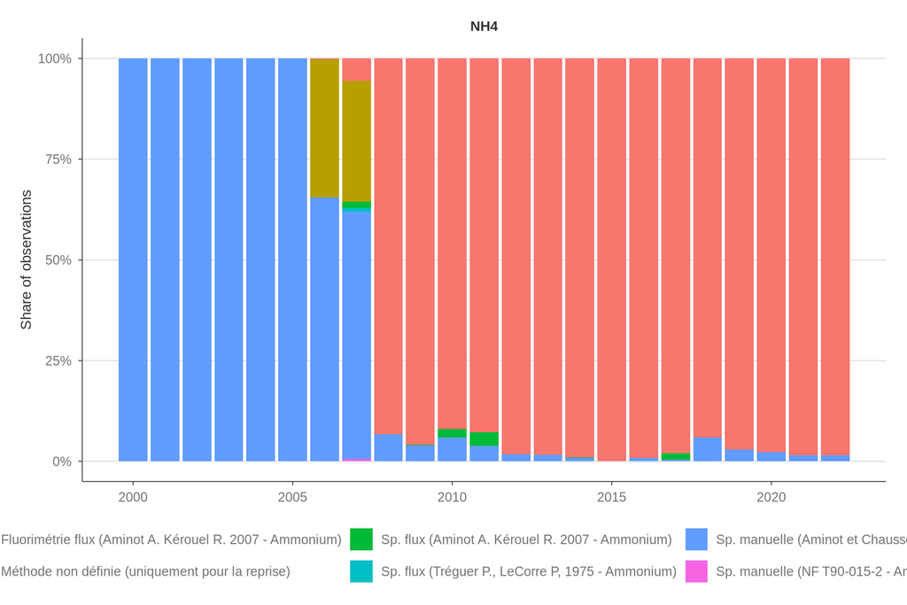

```r
method_share <- riversea::summarise_rephy_method_share(raw_data) |>
  mutate(method = stringr::str_replace(
    method,
    "Spectrophotométrie",
    "Sp."
  )) |>
  filter(year >= 2000)

riversea::plot_rephy_method_share(
  method_share |>
    filter(parameter_code == "NH4")
)
```

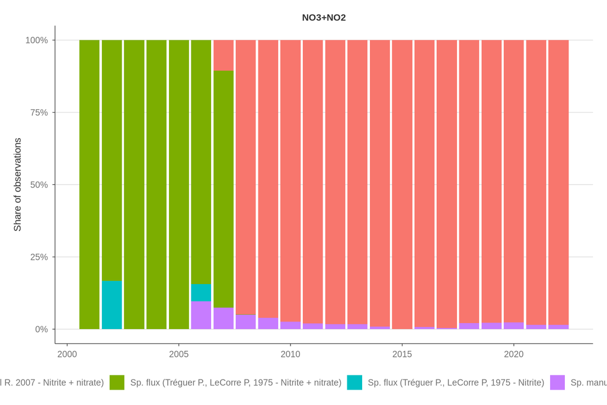

```r
riversea::plot_rephy_method_share(
  method_share |>
    filter(parameter_code == "NO3+NO2")
)
```

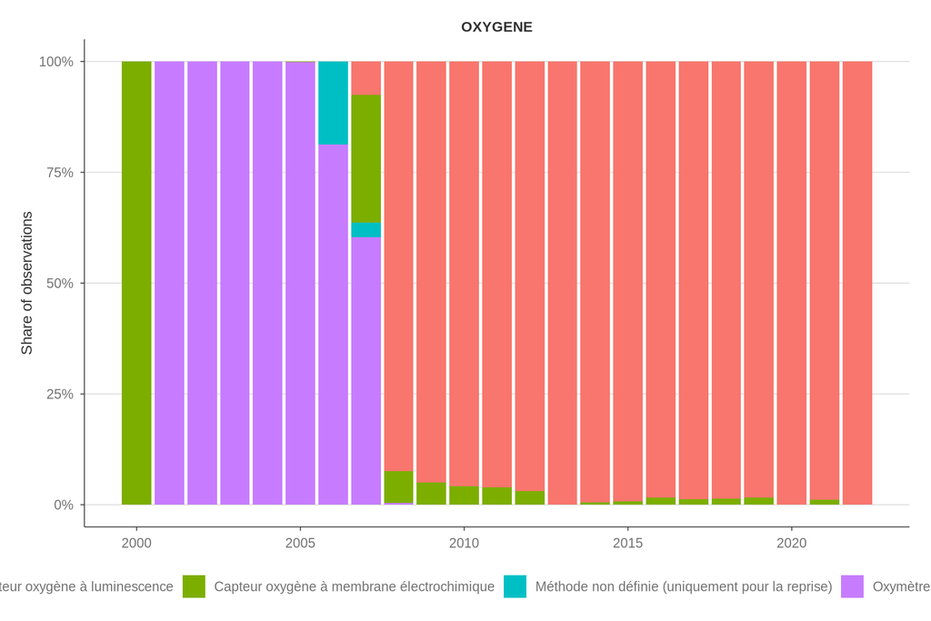

```r
riversea::plot_rephy_method_share(
  method_share |>
    filter(parameter_code == "OXYGENE")
)
```

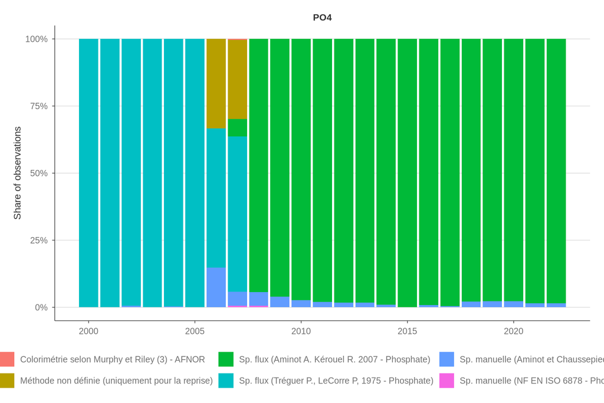

```r
riversea::plot_rephy_method_share(
  method_share |>
    filter(parameter_code == "PO4")
)
```

We notice a change in measurement methods for all parameters around 2006.

### Focus on one station

We can try to see if this change of method is reflected in nutrient concentration by looking at a station where the change occurred.

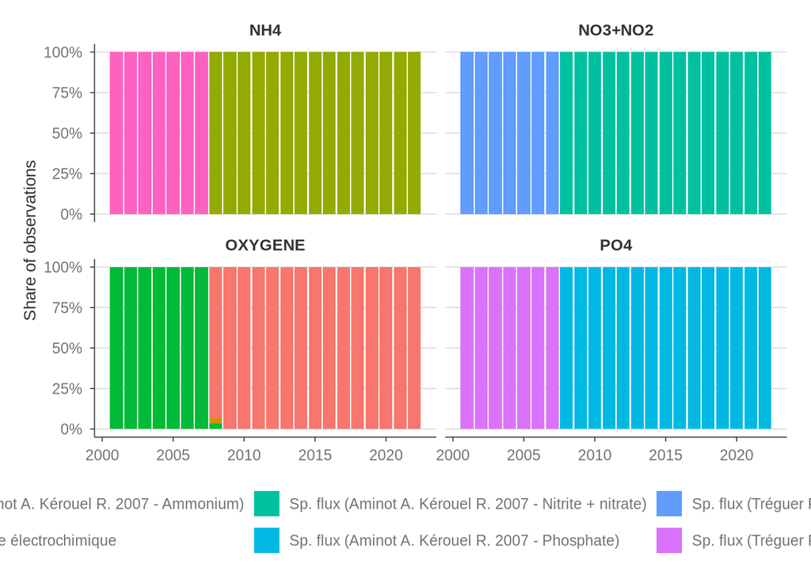

```r
site <- site_most_point

data_site <- raw_data |>
  filter(`Lieu de surveillance : Identifiant` == site)

method_share_site <- riversea::summarise_rephy_method_share(data_site) |>
  mutate(method = stringr::str_replace(
    method,
    "Spectrophotométrie",
    "Sp."
  )) |>
  filter(year >= 2000)

riversea::plot_rephy_method_share(method_share_site)
```

So for this station there is a clear change in sampling method. Let’s see if it is reflected in nutrient values.

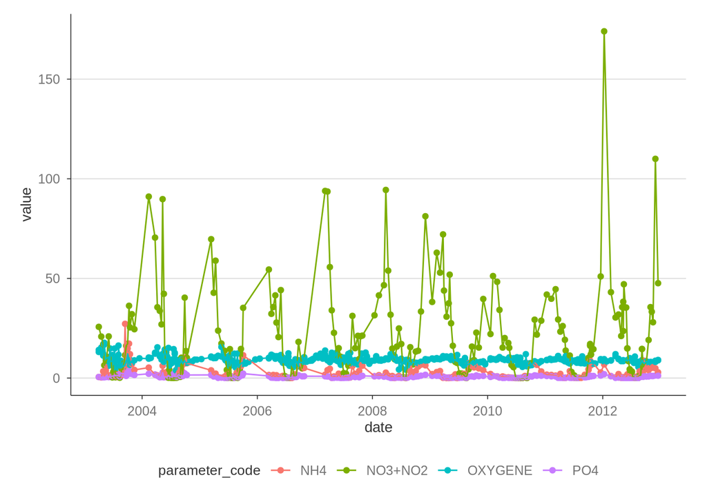

```r
data_most_point <- data |>
  filter(site_id == site_most_point) |>
  filter(lubridate::year(date) >= 2003 & lubridate::year(date) <= 2012)

ggplot(data_most_point, aes(x = date, y = value, color = parameter_code)) +
  geom_point() +
  geom_line()
```

Luckily, we see that the change of methods doesn’t seem to cause a change in nutrient values.

## Sampling quality

We inspect that quality of the data collected across the year.

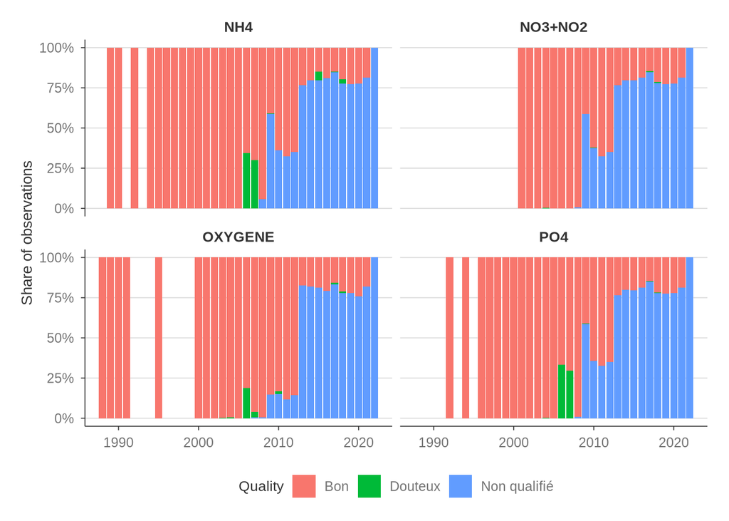

```r
raw_data |>
  summarise_rephy_quality_share() |>
  plot_rephy_quality_share()
```

## Depth

Now we investigate the distrubtion of the depths at which variable are measured.

```r
data |>
  filter_out(is.na(level)) |>
  group_by(parameter_code, level) |>
  summarise(n = n()) |>
  arrange(parameter_code, desc(n)) |>
  print(n = 30)
```

```
# A tibble: 30 × 3
# Groups:   parameter_code [4]
   parameter_code level                                     n
   <chr>          <chr>                                 <int>
 1 NH4            Surface (0-1m)                        18637
 2 NH4            Mi-profondeur                           487
 3 NH4            Fond/sonde-1m                           123
 4 NH4            de 3 à 5 mètres                          32
 5 NH4            Surface-Fond (profondeur <3 m)            1
 6 NH4            de 6 à 10 mètres                          1
 7 NO3+NO2        Surface (0-1m)                        18758
 8 NO3+NO2        Fond/sonde-1m                            65
 9 NO3+NO2        Mi-profondeur                            28
10 NO3+NO2        Surface-Fond (profondeur <3 m)            1
11 NO3+NO2        de 6 à 10 mètres                          1
```

[output cut: 19 more lines]

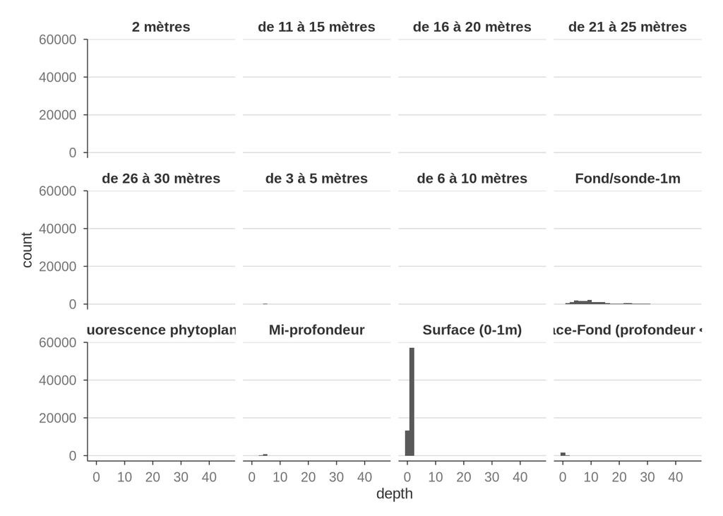

```r
ggplot(data |> filter_out(is.na(depth)), aes(x = depth)) +
  geom_histogram() +
  facet_wrap(~level)
```

We see that apart from oxygene variables are mainly measured at the surface. That means we can focus on this depth, and remove other depths.

For more details, we can check how variable change with depth.

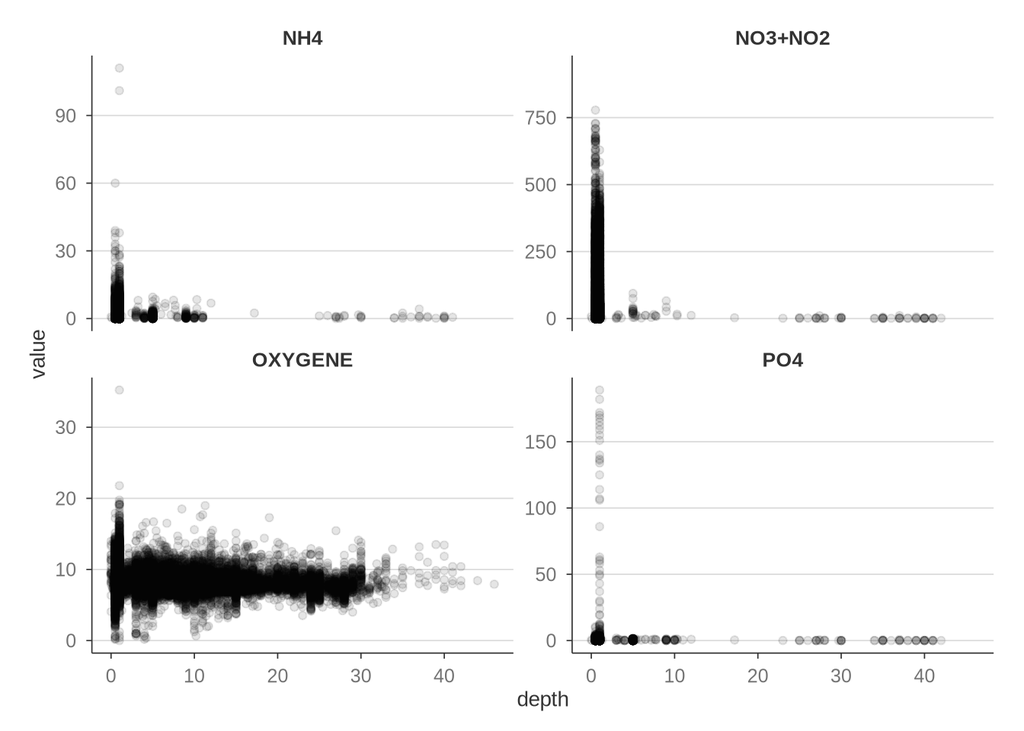

```r
ggplot(data, aes(x = depth, y = value)) +
  geom_point(alpha = 0.1) +
  facet_wrap(~parameter_code, scales = "free_y")
```

We see that oxygen is relatively constant meaning that using the surface concentration is representative of the rest of the water column. We keep only surface measurements in the following dataframe.

```r
str(tar_read(rephy_data_surface))
```

```
tibble [71,984 × 12] (S3: tbl_df/tbl/data.frame)
 $ site_id        : num [1:71984] 1e+06 1e+06 1e+06 1e+06 1e+06 ...
 $ site_label     : chr [1:71984] "Strouanne" "Strouanne" "Strouanne" "Strouanne" ...
 $ sample_id      : num [1:71984] 50157 50157 50158 50158 50159 ...
 $ date           : Date[1:71984], format: "1989-02-09" "1989-02-09" ...
 $ depth          : num [1:71984] 0.5 0.5 0.5 0.5 0.5 0.5 0.5 0.5 0.5 0.5 ...
 $ depth_unit     : chr [1:71984] "m" "m" "m" "m" ...
 $ longitude      : num [1:71984] 1.68 1.68 1.68 1.68 1.68 ...
 $ latitude       : num [1:71984] 50.9 50.9 50.9 50.9 50.9 ...
 $ parameter_code : chr [1:71984] "NH4" "OXYGENE" "NH4" "OXYGENE" ...
 $ parameter_label: chr [1:71984] "Ammonium" "Oxygène dissous" "Ammonium" "Oxygène dissous" ...
 $ value          : num [1:71984] 0.15 9.23 0.15 7.39 0.15 ...
 $ unit           : chr [1:71984] "µmol.l-1" "mg.l-1" "µmol.l-1" "mg.l-1" ...
```